# Red Wine Quality by Alex Raya

```
##   fixed.acidity volatile.acidity citric.acid residual.sugar chlorides
## 1           7.4             0.70        0.00            1.9     0.076
## 2           7.8             0.88        0.00            2.6     0.098
## 3           7.8             0.76        0.04            2.3     0.092
## 4          11.2             0.28        0.56            1.9     0.075
## 5           7.4             0.70        0.00            1.9     0.076
## 6           7.4             0.66        0.00            1.8     0.075
##   free.sulfur.dioxide total.sulfur.dioxide density   pH sulphates alcohol
## 1                  11                   34  0.9978 3.51      0.56     9.4
## 2                  25                   67  0.9968 3.20      0.68     9.8
## 3                  15                   54  0.9970 3.26      0.65     9.8
## 4                  17                   60  0.9980 3.16      0.58     9.8
## 5                  11                   34  0.9978 3.51      0.56     9.4
## 6                  13                   40  0.9978 3.51      0.56     9.4
##   quality
## 1       5
## 2       5
## 3       5
## 4       6
## 5       5
## 6       5
```

> This is a Udacity dataset on the chemical properties of red wine with 11 variables, along with a quality column from 3 judges that rates the wine from 0 (very bad) to 10 (excellent), and this exploratory analysis is to better understand what chemical properties are most impactful upon the quality of red wine.

# Univariate Plots Section

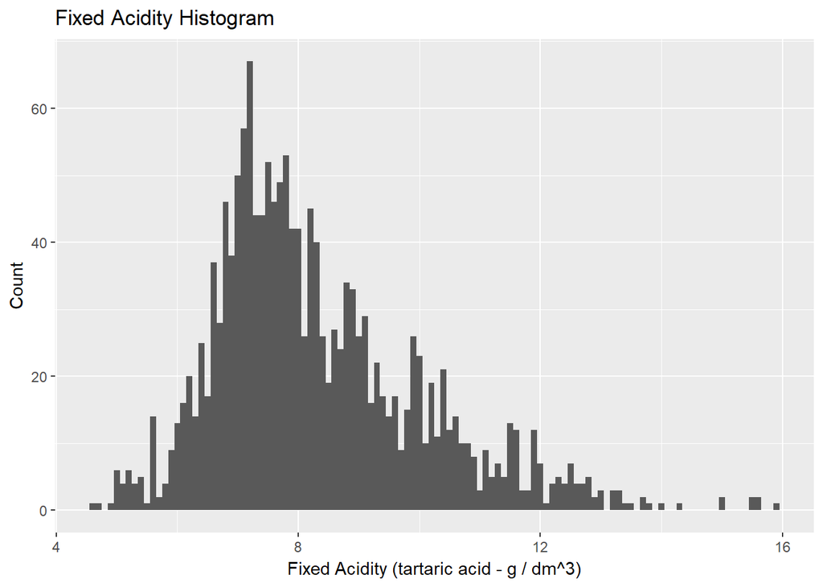

> This is an intial plot displaying the distribution of fixed acidity in the dataset.

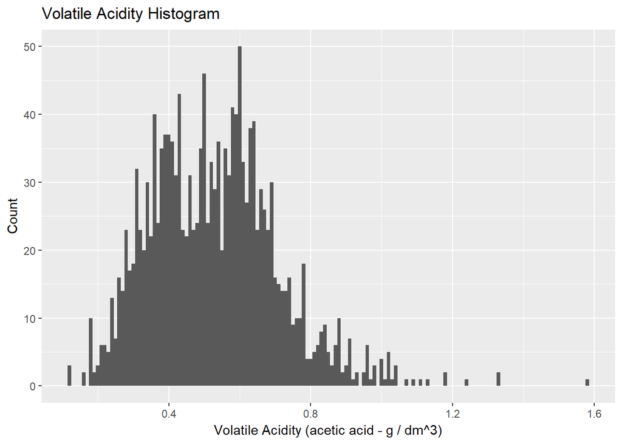

> This plot displays the distribution of volatile acidity in the dataset, which looks fairly familiar to the distributive appearance for fixed acidity.

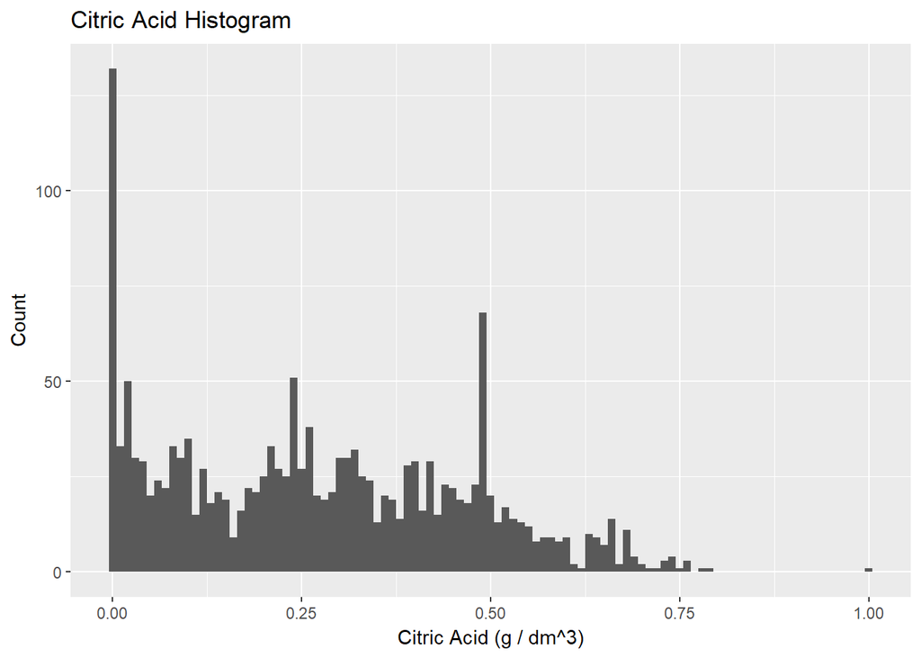

> This plot displays the distribution of citric.acid in the dataset, which shows the existence of many values = 0.

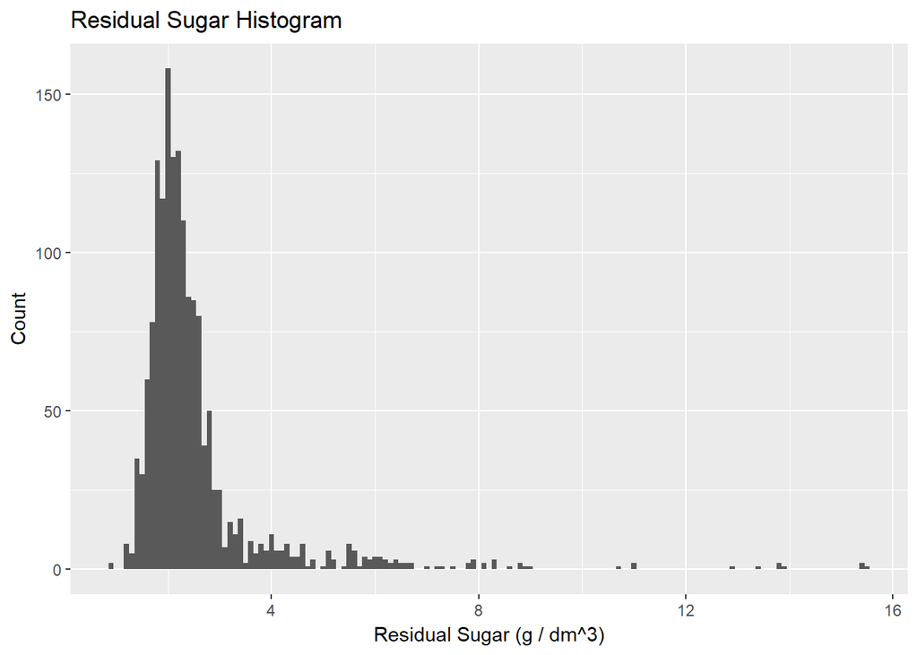

> This plot for residual sugar shows that sugar has many outlier values that skew the data, beyond about the value of 4.

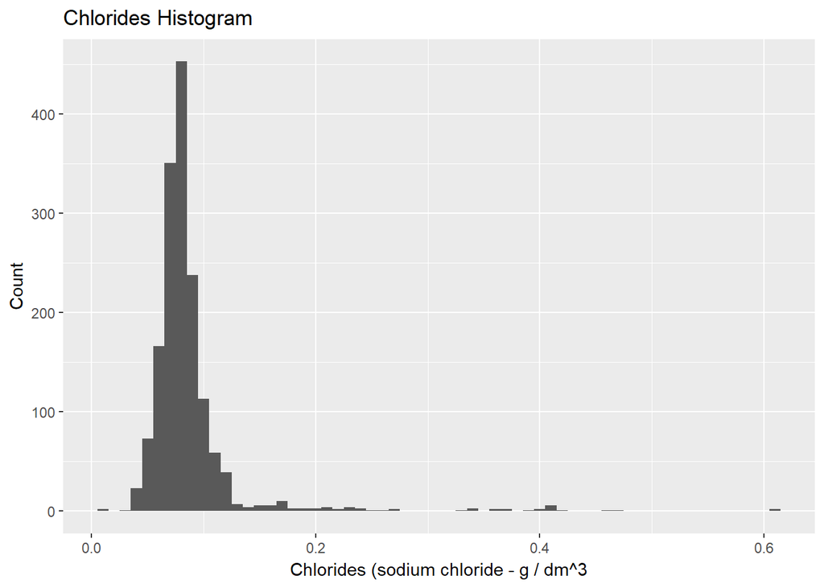

> This plot for chlorides displays a data pattern similar to residual sugar where there are lots of outlier values that skew the data, a good limit being about 0.15 or so to eliminate outliers.

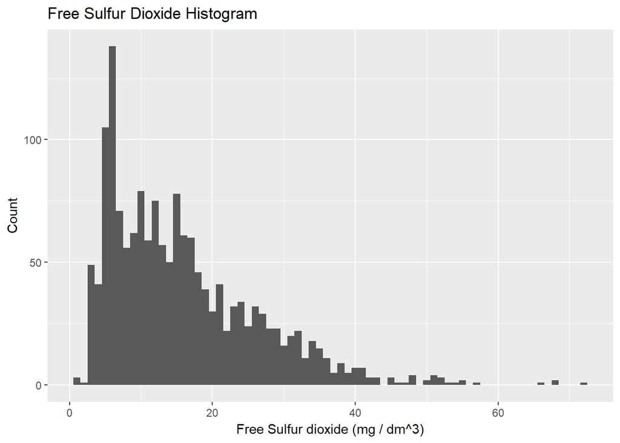

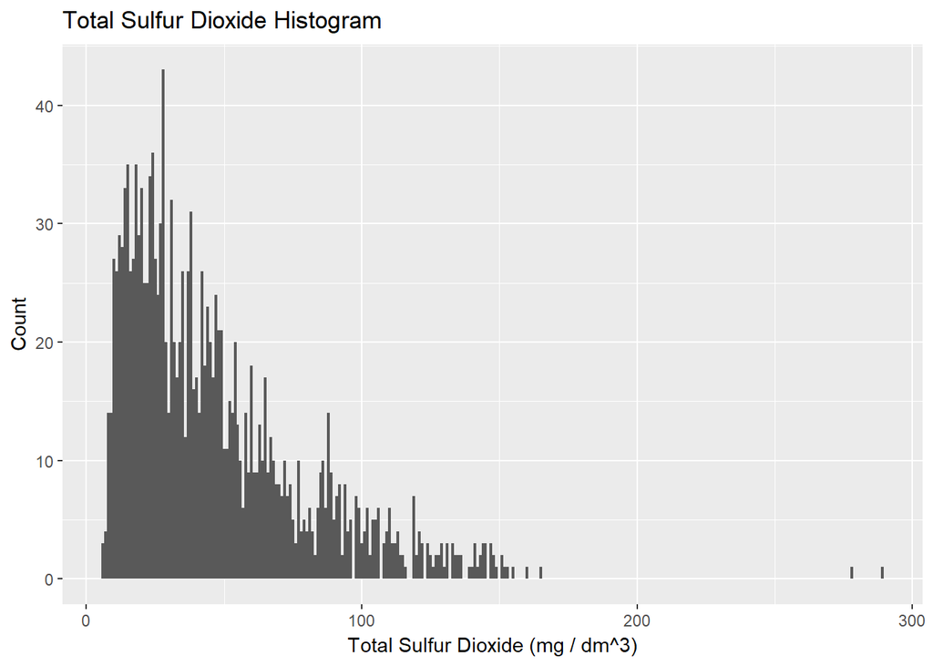

> These plots for free and total sulfur dioxide also display skews due to outliers, beyond about a limit of 40 for free and 150 for total sulfur dioxide.

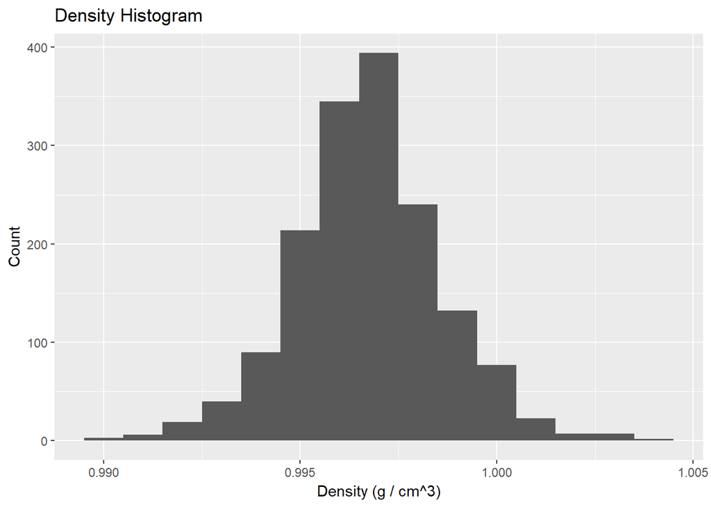

> The plot for density displays a normalized standard distribution, but the variance for most values is very small.

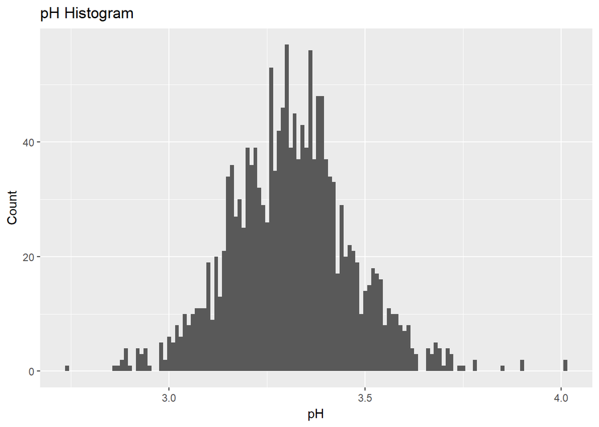

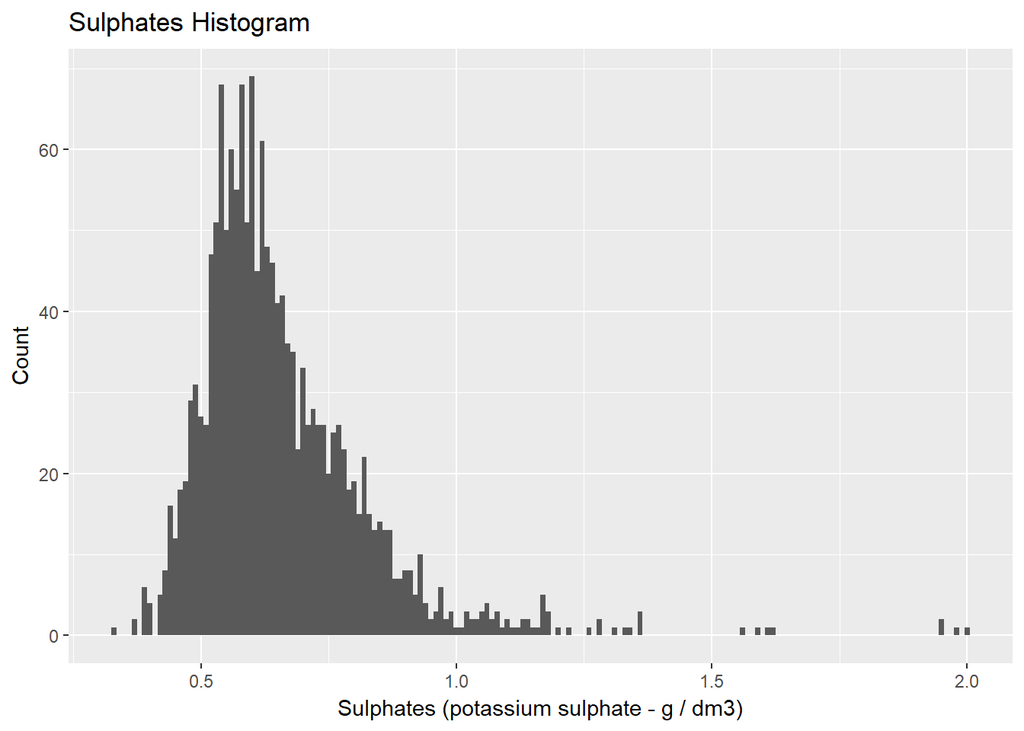

> The plot for sulphates displays large outliers like the other plots, beyond a limit of about 1.

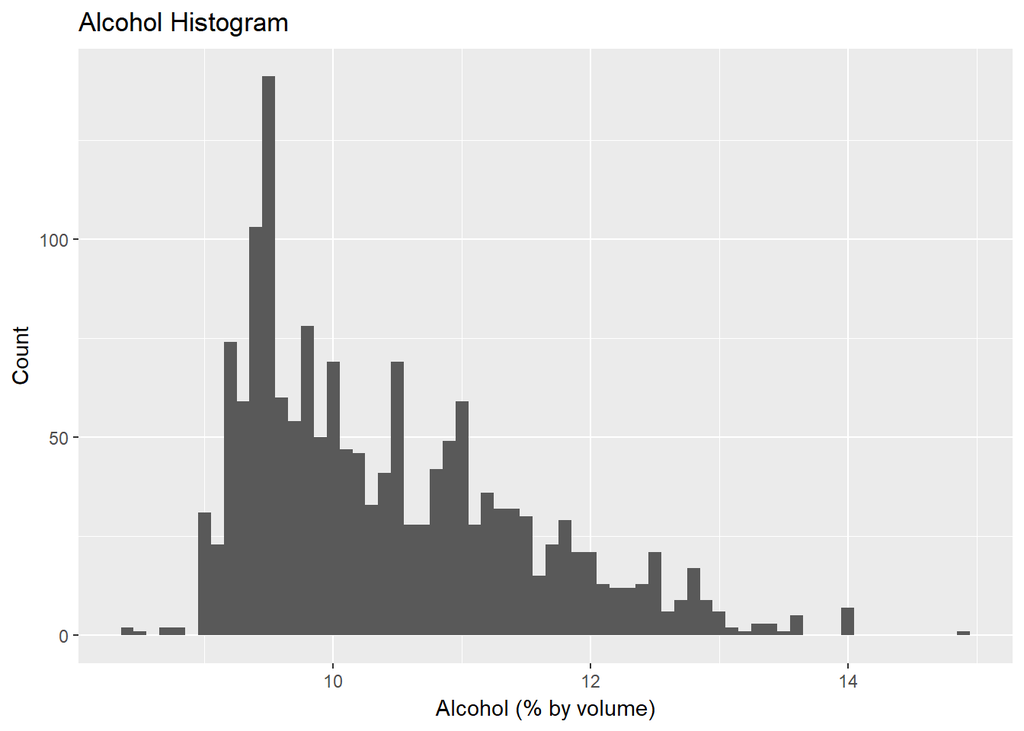

> This plot for alcohol displays most values being between about 8 and 14.

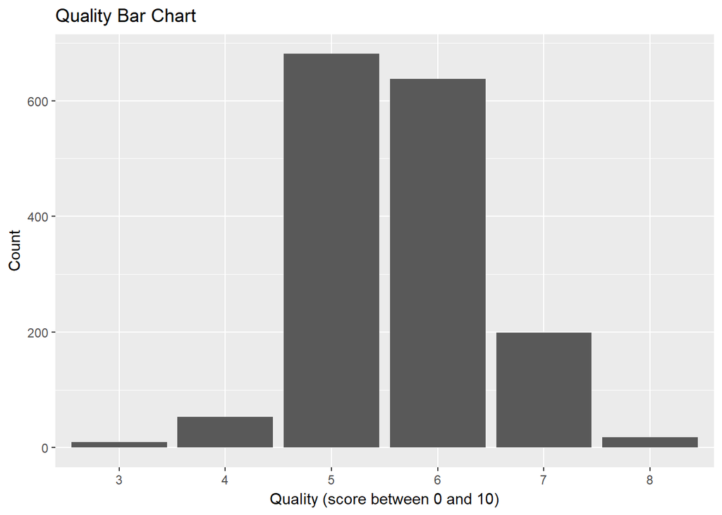

> From the plot for quality an interesting aspect of this dataset is displayed, despite being on a scale of 0 to 10, quality is almost entirely concentrated within the values of 5 and 6, with some wines rating 7, very few at 8 or lower than 5, and none higher than 8. This skew may impact what the outcome of the analysis is.

# Univariate Analysis

```
##  fixed.acidity   volatile.acidity  citric.acid    residual.sugar
##  Min.   : 4.60   Min.   :0.1200   Min.   :0.000   Min.   : 0.900
##  1st Qu.: 7.10   1st Qu.:0.3900   1st Qu.:0.090   1st Qu.: 1.900
##  Median : 7.90   Median :0.5200   Median :0.260   Median : 2.200
##  Mean   : 8.32   Mean   :0.5278   Mean   :0.271   Mean   : 2.539
##  3rd Qu.: 9.20   3rd Qu.:0.6400   3rd Qu.:0.420   3rd Qu.: 2.600
##  Max.   :15.90   Max.   :1.5800   Max.   :1.000   Max.   :15.500
##    chlorides       free.sulfur.dioxide total.sulfur.dioxide
##  Min.   :0.01200   Min.   : 1.00       Min.   :  6.00
##  1st Qu.:0.07000   1st Qu.: 7.00       1st Qu.: 22.00
##  Median :0.07900   Median :14.00       Median : 38.00
##  Mean   :0.08747   Mean   :15.87       Mean   : 46.47
##  3rd Qu.:0.09000   3rd Qu.:21.00       3rd Qu.: 62.00
##  Max.   :0.61100   Max.   :72.00       Max.   :289.00
##     density             pH          sulphates         alcohol
##  Min.   :0.9901   Min.   :2.740   Min.   :0.3300   Min.   : 8.40
##  1st Qu.:0.9956   1st Qu.:3.210   1st Qu.:0.5500   1st Qu.: 9.50
##  Median :0.9968   Median :3.310   Median :0.6200   Median :10.20
##  Mean   :0.9967   Mean   :3.311   Mean   :0.6581   Mean   :10.42
##  3rd Qu.:0.9978   3rd Qu.:3.400   3rd Qu.:0.7300   3rd Qu.:11.10
##  Max.   :1.0037   Max.   :4.010   Max.   :2.0000   Max.   :14.90
##     quality
##  Min.   :3.000
##  1st Qu.:5.000
##  Median :6.000
##  Mean   :5.636
##  3rd Qu.:6.000
##  Max.   :8.000
```

```
##  fixed.acidity   volatile.acidity citric.acid     residual.sugar
##  Mode :logical   Mode :logical    Mode :logical   Mode :logical
##  FALSE:1599      FALSE:1599       FALSE:1599      FALSE:1599
##  chlorides       free.sulfur.dioxide total.sulfur.dioxide  density
##  Mode :logical   Mode :logical       Mode :logical        Mode :logical
##  FALSE:1599      FALSE:1599          FALSE:1599           FALSE:1599
##      pH          sulphates        alcohol         quality
##  Mode :logical   Mode :logical   Mode :logical   Mode :logical
##  FALSE:1599      FALSE:1599      FALSE:1599      FALSE:1599
```

### What is the structure of your dataset?

> This dataset has 1,599 entries for red wine with no null values, with columns for individual chemical composition values, some of which have outlier values that produce data skew, and notably the quality of the wine is largely composed of those who values are 5-6, which seems narrow given the 0-10 range for quality values.

### What is/are the main feature(s) of interest in your dataset?

> Analyzing the individual factors to see which are most significant in impacting the quality of the wine will be of interest, however the narrow range in values for quality in the dataset may hinder the analysis in providing substantive insight into how chemical composition impacts wine quality overall.

### What other features in the dataset do you think will help support your investigation into your feature(s) of interest?

> Because there are numerous variables to analyze, looking for initial impacts on quality, multivariable analysis and boxing or wrapping on plots may provide decent insight into the main factors affecting quality.

### Did you create any new variables from existing variables in the dataset?

> There are plenty of factors to examine and thus any new variables would only make this analysis more complicated probably.

### Of the features you investigated, were there any unusual distributions? Did you perform any operations on the data to tidy, adjust, or change the form of the data? If so, why did you do this?

> Several factors such as residual sugar, chlorides, sulfur dioxide and sulfates had outliers which could skew data when plotting those values, so those require attention when creating plots, and the skew on quality is to be considered when analyzing for relationships.

# Bivariate Plots Section

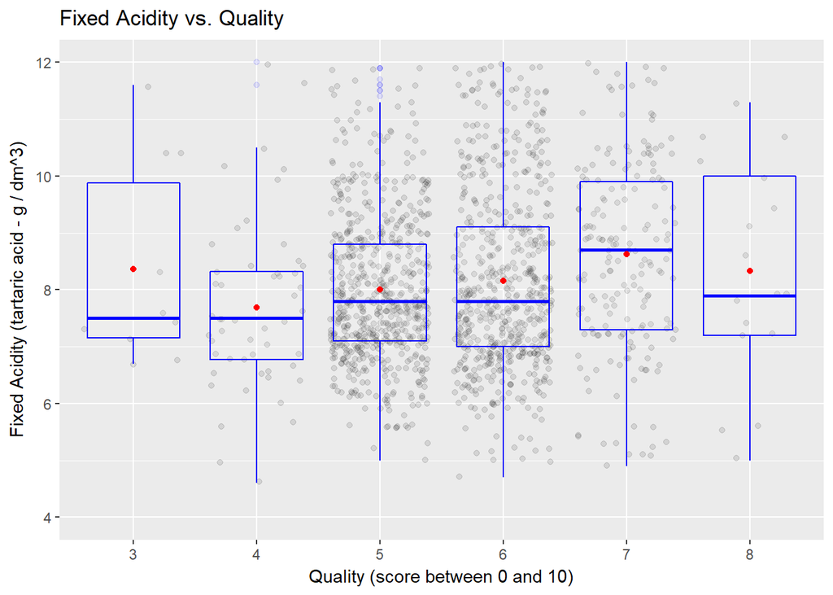

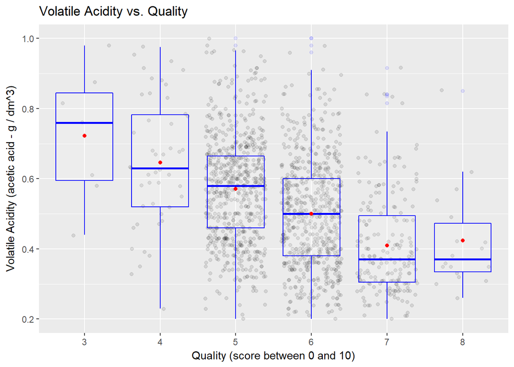

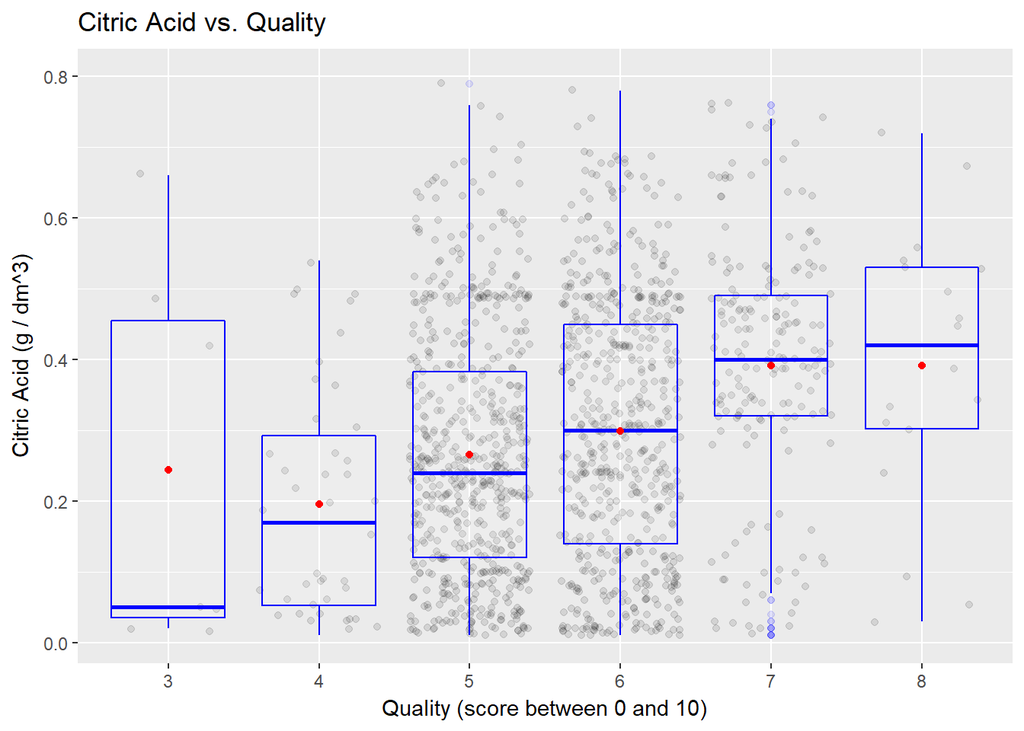

```
## Fixed acidity and Quality correlation: 0.124051649113224
```

```
## Volatile acidity and Quality correlation: -0.390557780264007
```

```
## Citric acid and Quality correlation: 0.226372514318041
```

> Fixed acidity does not appear to be much of a factor on quality, however volatile acidity seems to have some correlation, confirmed with a -0.39 Pearson coefficient calculation, citric acid also appears to have a correlation to quality but weaker according to the Pearson calculation of 0.23.

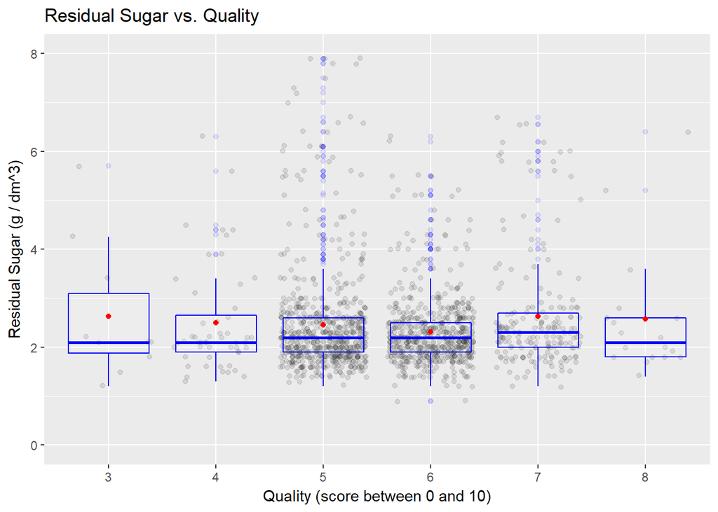

```
## Residual sugar and Quality correlation: 0.0137316373400663
```

> Residual sugar does not appear to be much of a factor with regards to correlating with quality, and by a Pearson coefficient calculation, has none.

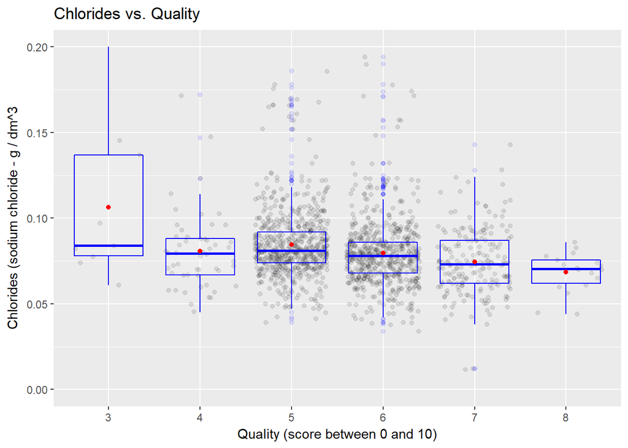

```
## Chlorides and Quality correlation: -0.128906559930053
```

> Chlorides do not appear to have correlation with quality, and the Pearson correlation calculation is weak at -0.13.

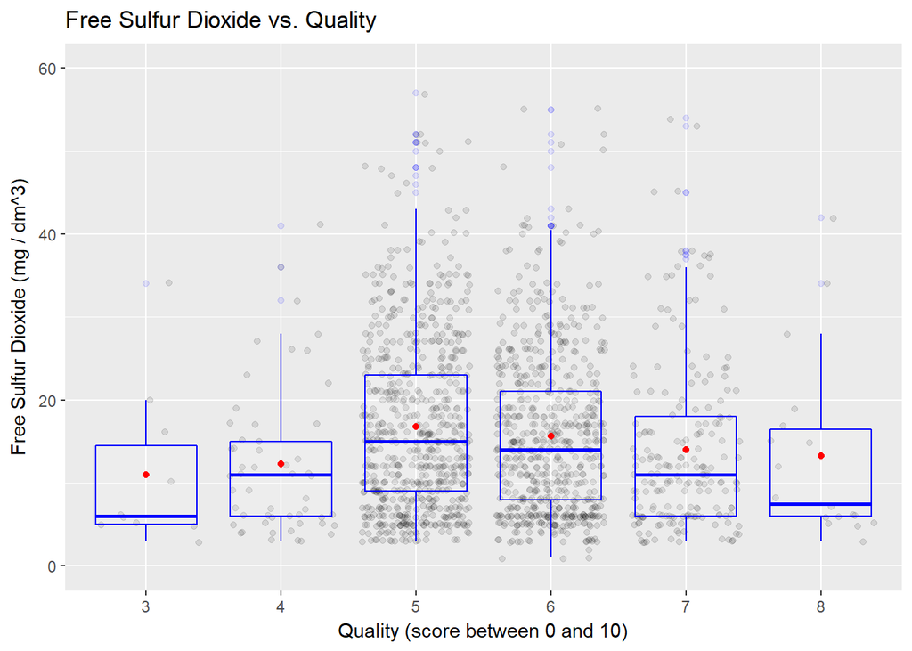

```
## Free sulfur dioxide and Quality correlation: -0.0506560572442764
```

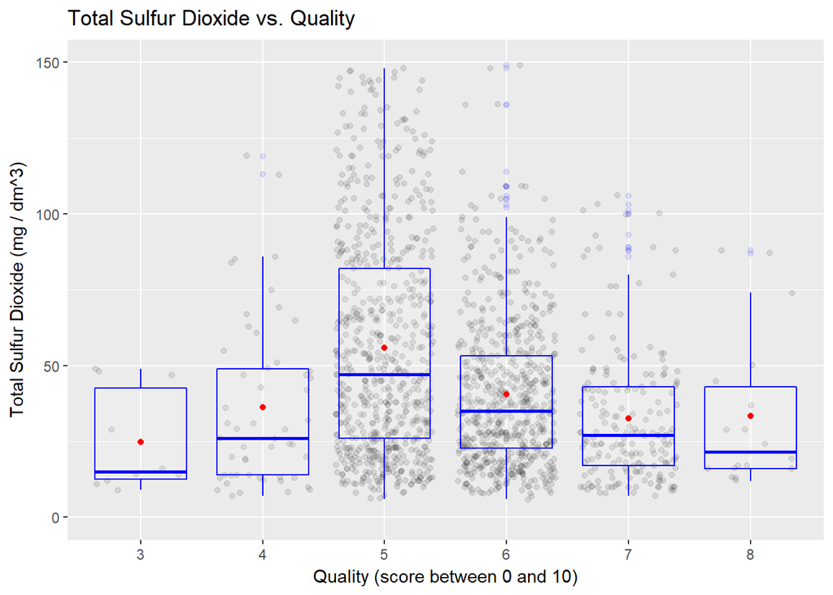

```
## Total sulfur dioxide and Quality correlation: -0.185100288926538
```

> Free and total sulfur dioxide have a peculiar spiking pattern versus quality, and though total sulfur dioxide has some correlation to quality according to the Pearson coefficient calculation, they will be ignored due to the appearance of their data distributions and presumed weak correlation.

[figure not shown]

```
## Density and Quality correlation: -0.174919227783349
```

> Density appears to have some correlation with quality, but is weak.

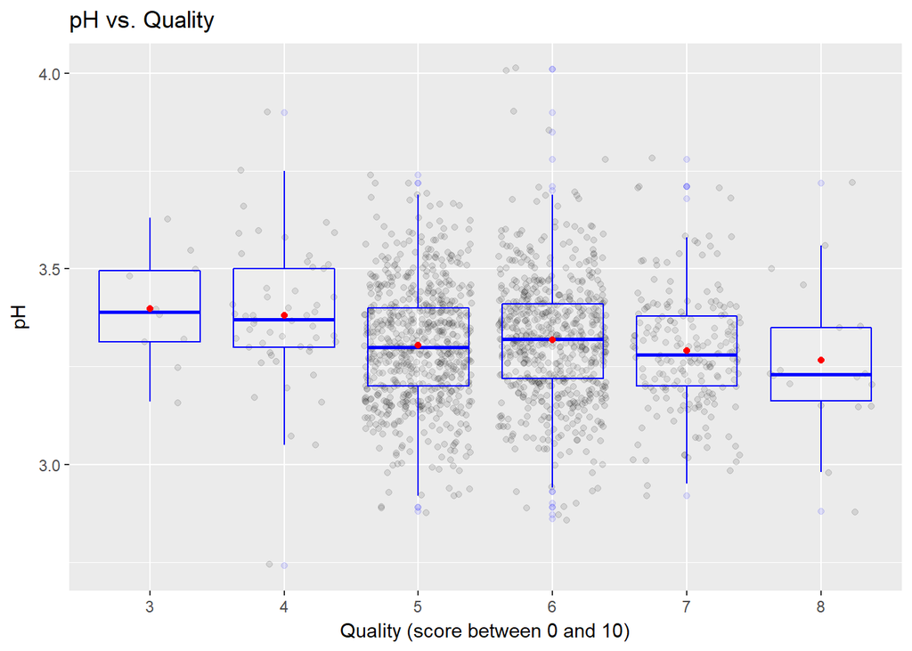

```
## pH and Quality correlation: -0.0577313912053821
```

> pH does not appear to correlate with quality, and has none according to the Pearson coefficient calculation.

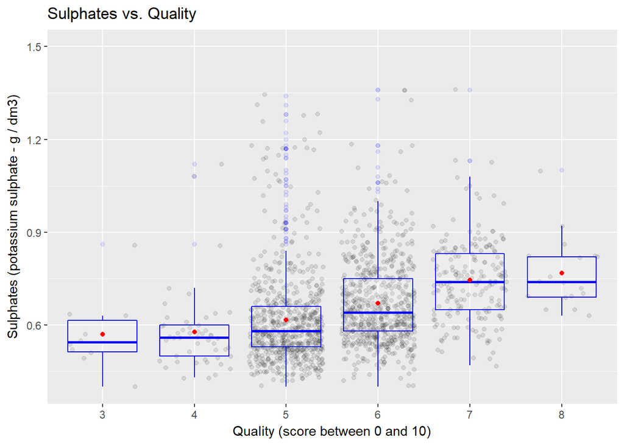

```
## Sulphates and Quality correlation: 0.251397079069261
```

> Sulphates appear to correlative positively with quality somewhat, and according to Pearson coefficient calculation, is not very weak at 0.25.

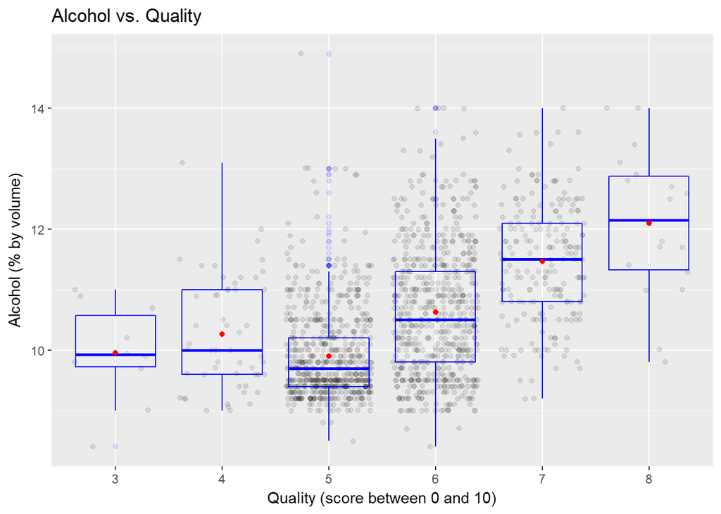

```
## Alcohol and Quality correlation: 0.476166324001136
```

> Alcohol appears to have a positive correlation with quality, and is not weak by the Pearson calculation of 0.48.

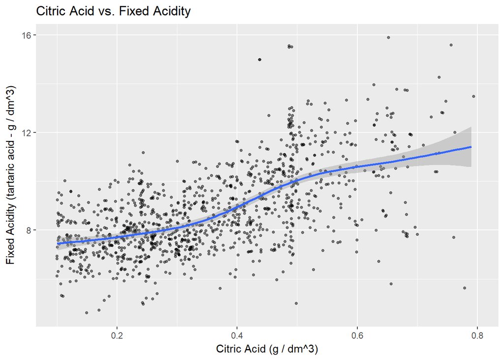

```
## [1] 0.6717034
```

> Citric acid and fixed acidity have a strong correlation with each other of 0.67.

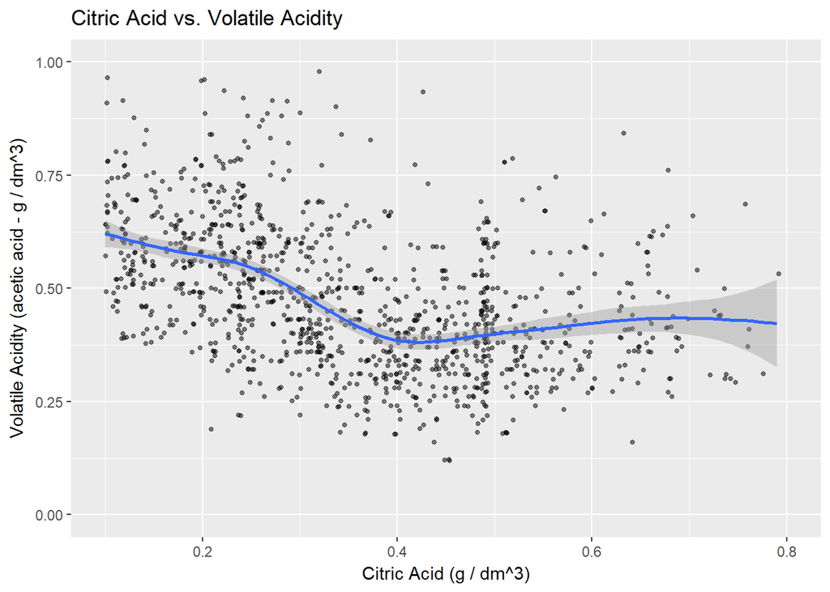

```
## Citric acid and volatile acidity correlation: -0.55249568455958
```

```
## Fixed acidity and volatile acidity correlation: -0.256130894770382
```

> Fixed acidity and volatile acidity only have a -0.26 Pearson correlation coefficient, which is interesting that citric acid correlates with both of them strongly, yet fixed and volatile acidity values correlate to themselves weakly.

# Bivariate Analysis

### Talk about some of the relationships you observed in this part of the investigation. How did the feature(s) of interest vary with other features in the dataset?

> Variables with decent correlations to quality to consider are volatile acidity, citric acid, sulphates and alcohol, however with the exceptions of volatile acidity and alcohol, most of these correlations are rather weak (below +/-0.3), so I am going with values whose correlations are above +/- 0.2 to proceed with the analysis further, which brings in citric acid and sulphates at least.

### Did you observe any interesting relationships between the other features (not the main feature(s) of interest)?

> Citric acid strongly correlates with fixed and volatile acidity, which is not really surprising since those are all measurements of acidity to some degree, however what is interesting is that fixed and volatile acidity do not correlate to each other strongly.

### What was the strongest relationship you found?

> The strongest and most amusing relationship was alcohol to quality, which did not seem obvious since alcohol is a basic component of wine, but I did not think initially that alcohol content per se would be such a strong factor on how a wine would be rated since it seems like such an elementary component, I would think other factors would be more impactful in differentiating how a wine is rated than just the alcohol content.

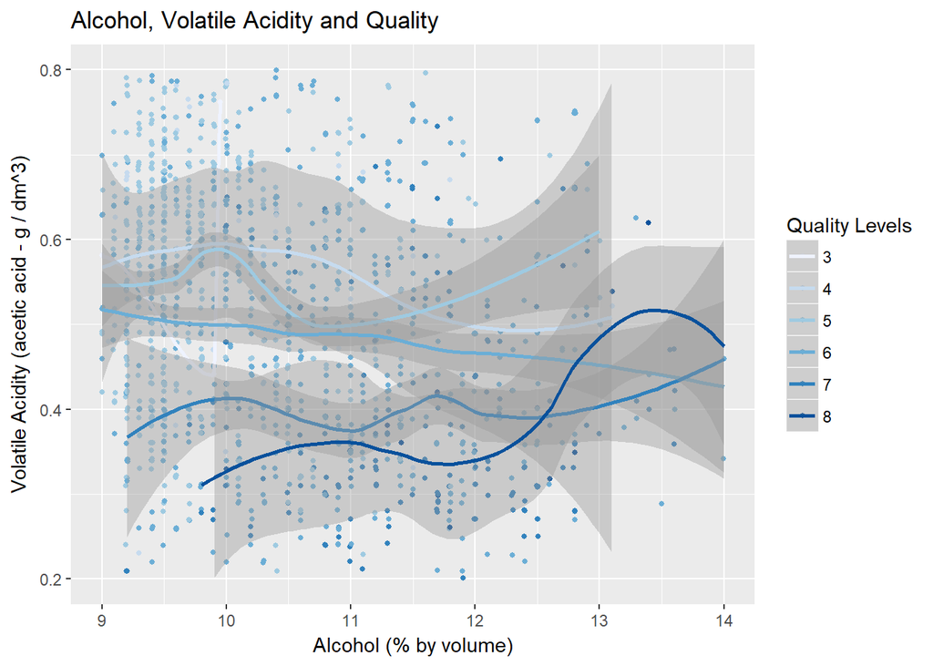

```
## Alcohol and volatile acidity correlation: -0.202288027153256
```

> This is a scatter plot with a smooth trend to look at alcohol versus volatile acidity by quality levels, and alcohol and volatile acidity have some correlation, and as wine quality increases, volatile acidity decreases, for about all alcohol levels.

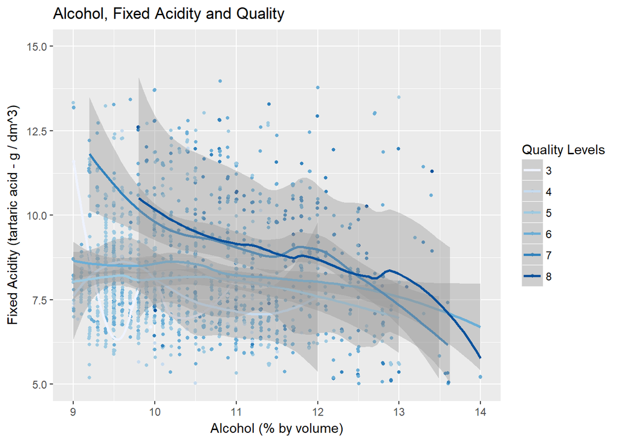

```
## Alcohol and fixed acidity correlation: -0.0616682706281511
```

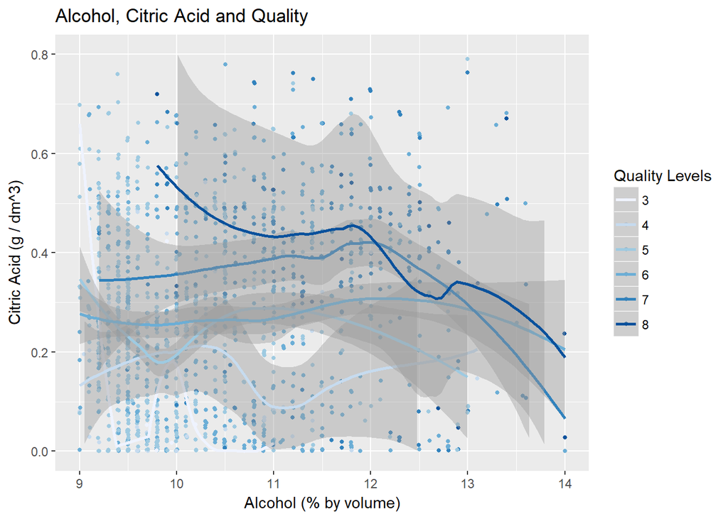

```
## Alcohol and citric acid correlation: 0.109903246641567
```

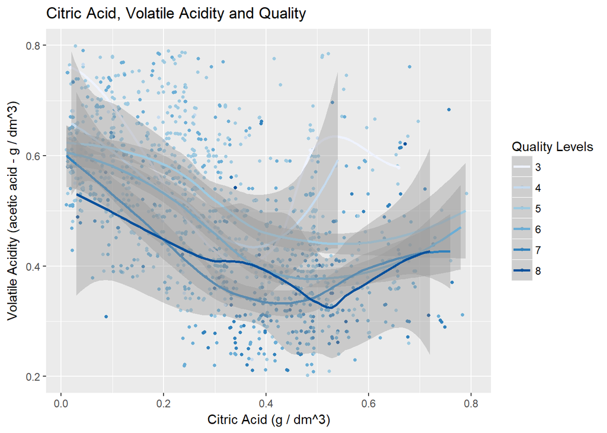

```
## Citric acid and volatile acidity correlation: -0.55249568455958
```

> This scatter plot with a smooth trend to look at citric acid versus volatile acidity by quality level shows a strong negative correlation between the two.

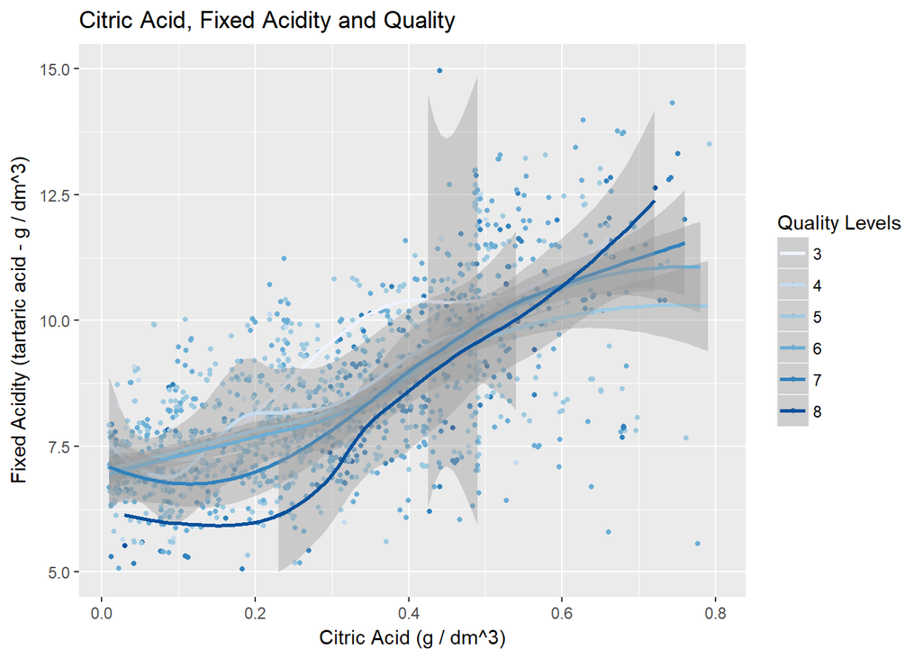

```
## Citric acid and fixed acidity correlation: 0.671703434764106
```

> Similar to the last plot, this scatter plot with a smooth trend to look at citric acid versus fixed acidity by quality level shows a very strong correlation, this one positive.

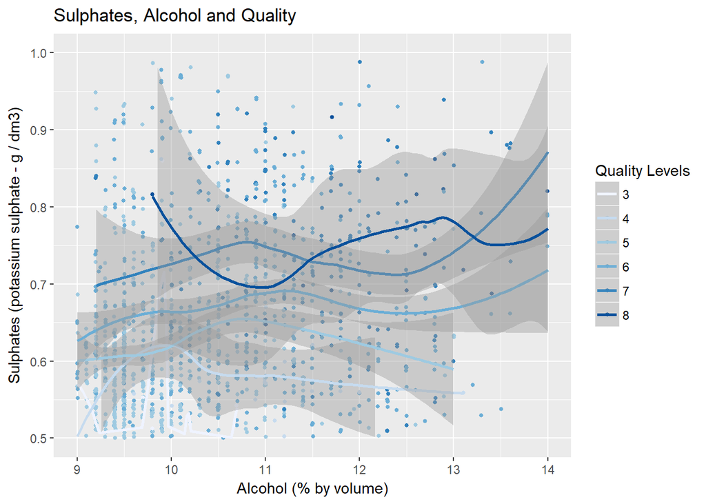

```
## Alcohol and sulphates correlation: 0.0935947504104674
```

> This scatter plot with a smooth trend to look at alcohol versus sulphates by quality level shows that higher quality wines had higher sulphates at every alcohol level, with the wines rated 8 exhibiting odd compositional trends as the exception.